# olsrr

{olsrr}: Tools for Building OLS Regression Models

- Tools designed to make it easier for users, particularly beginner/intermediate R users to build ordinary least squares regression models.
- Includes comprehensive regression output, heteroskedasticity tests, collinearity diagnostics, residual diagnostics, measures of influence, model fit assessment and variable selection procedures.
- Author: Aravind Hebbali

(Source: CRAN)

# Diagnostics panel

Panel of plots for regression diagnostics.

```
ols_plot_diagnostics(model)
```

#### Arguments

- `model`: An object of class lm.

# Diagnostics panel

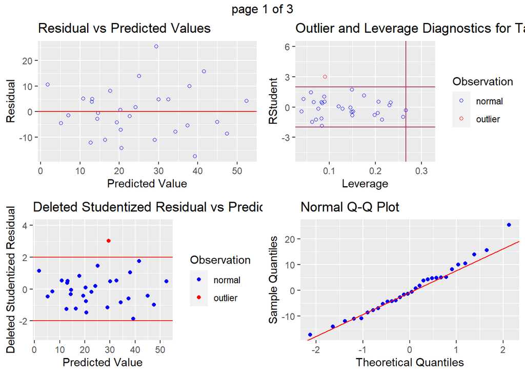

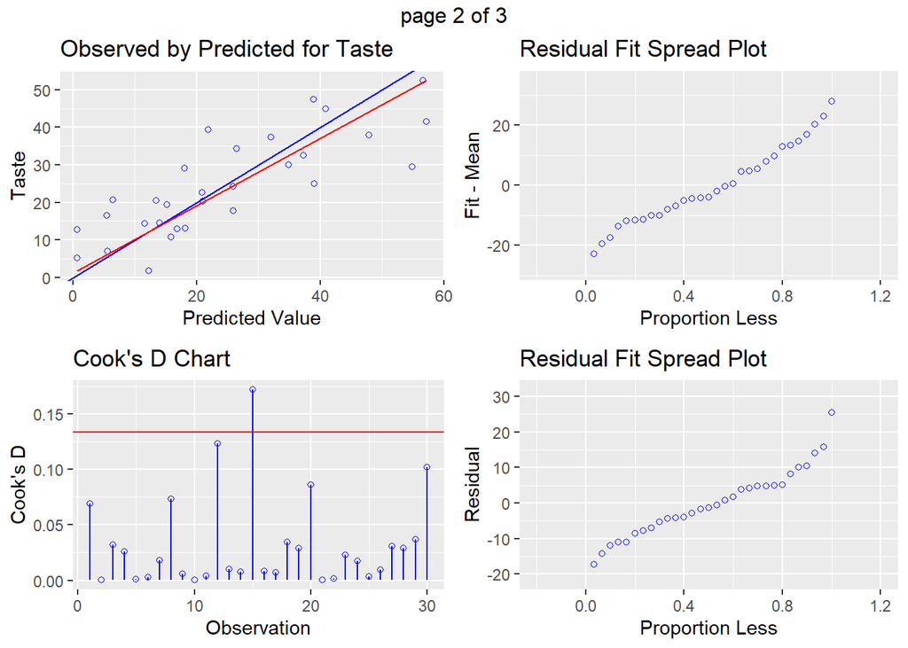

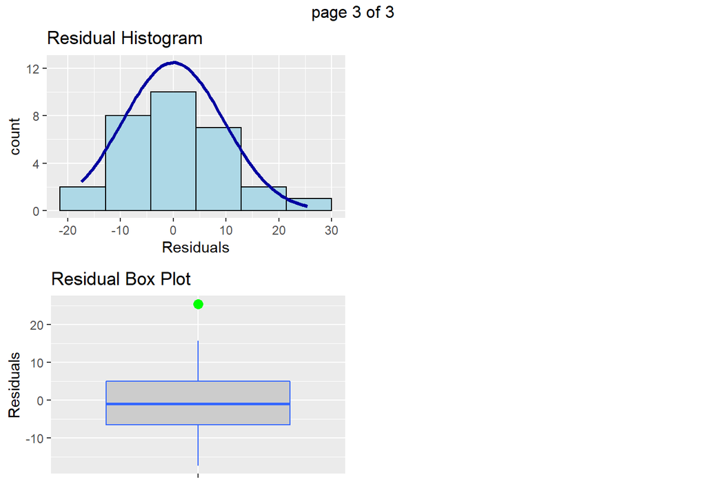

```r
model <- Fit_4
ols_plot_diagnostics(model)
```

# `Residual QQ plot`

#### Description

Graph for detecting violation of normality assumption.

```
ols_plot_resid_qq(model)
```

# Residual QQ plot

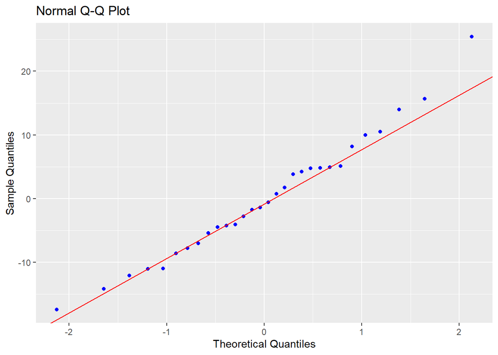

```r
ols_plot_resid_qq(model)
```

# `ols_plot_resid_box()`

Box plot of residuals to examine if residuals are normally distributed.

```
ols_plot_resid_box(model)
```

# `ols_plot_resid_box()`

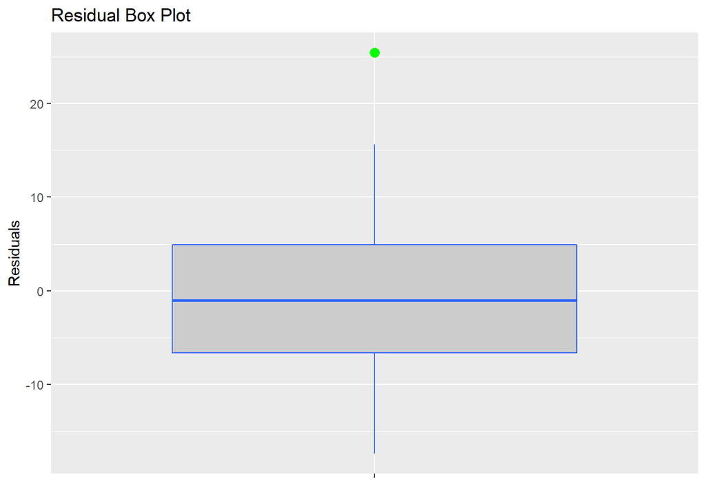

```r
ols_plot_resid_box(model)
```

# Breusch pagan test

#### Description

Test for constant variance. It assumes that the error terms are normally distributed.

```
ols_test_breusch_pagan(model, fitted.values = TRUE, rhs = FALSE,
                       multiple = FALSE,
                       p.adj = c("none", "bonferroni", "sidak", "holm"),
                       vars = NA)
```

# Breusch pagan test

- Breusch Pagan Test was introduced by Trevor Breusch and Adrian Pagan in 1979.
- It is used to test for heteroscedasticity in a linear regression model.
- It tests whether variance of errors from a regression is dependent on the values of a independent variable.

# Breusch pagan test

#### Value

An object of class "`ols_test_breusch_pagan`" is a list containing the following components:

- bp : breusch pagan statistic
- p : p-value of bp
- fv : fitted values of the regression model
- rhs : names of explanatory variables of fitted regression model
- multiple logical value indicating if multiple tests should be performed
- padj : adjusted p values
- vars : variables to be used for heteroskedasticity test
- resp : response variable
- preds : predictors

# Breusch pagan test

```r
# model

# use fitted values of the model

ols_test_breusch_pagan(model)
```

```
##
##  Breusch Pagan Test for Heteroskedasticity
##  -----------------------------------------
##  Ho: the variance is constant
##  Ha: the variance is not constant
##
##               Data
##  ---------------------------------
##  Response : Taste
##  Variables: fitted values of Taste
##
##         Test Summary
##  ----------------------------
##  DF            =    1
##  Chi2          =    1.157465
##  Prob > Chi2   =    0.2819919
```

# Breusch pagan test

```r
# use independent variables of the model
ols_test_breusch_pagan(model, rhs = TRUE)
```

```
##
##  Breusch Pagan Test for Heteroskedasticity
##  -----------------------------------------
##  Ho: the variance is constant
##  Ha: the variance is not constant
##
##             Data
##  ----------------------------
##  Response : Taste
##  Variables: Acetic H2S Lactic
##
##         Test Summary
##  ----------------------------
##  DF            =    3
##  Chi2          =    4.493994
##  Prob > Chi2   =    0.2128266
```

# Breusch pagan test

```r
# use independent variables of the model and perform multiple tests
ols_test_breusch_pagan(model, rhs = TRUE, multiple = TRUE)
```

```
##
##  Breusch Pagan Test for Heteroskedasticity
##  -----------------------------------------
##  Ho: the variance is constant
##  Ha: the variance is not constant
##
##             Data
##  ----------------------------
##  Response : Taste
##  Variables: Acetic H2S Lactic
##
##         Test Summary (Unadjusted p values)
##  -----------------------------------------------
##   Variable           chi2       df        p
##  -----------------------------------------------
##   Acetic           3.8855767     1    0.04870253
##   H2S              0.5192075     1    0.47117994
##   Lactic           1.6874864     1    0.19393265
##  -----------------------------------------------
##   simultaneous     4.4939942     3    0.21282661
##  -----------------------------------------------
```

# Breusch pagan test

```r
# bonferroni p value adjustment
ols_test_breusch_pagan(model, rhs = TRUE, multiple = TRUE, p.adj = 'bonferroni')
```

```
##
##  Breusch Pagan Test for Heteroskedasticity
##  -----------------------------------------
##  Ho: the variance is constant
##  Ha: the variance is not constant
##
##             Data
##  ----------------------------
##  Response : Taste
##  Variables: Acetic H2S Lactic
##
##         Test Summary (Bonferroni p values)
##  ----------------------------------------------
##   Variable           chi2       df        p
##  ----------------------------------------------
##   Acetic           3.8855767     1    0.1461076
##   H2S              0.5192075     1    1.0000000
##   Lactic           1.6874864     1    0.5817979
##  ----------------------------------------------
##   simultaneous     4.4939942     3    0.2128266
##  ----------------------------------------------
```

# Breusch pagan test

```r
# sidak p value adjustment
ols_test_breusch_pagan(model, rhs = TRUE, multiple = TRUE, p.adj = 'sidak')
```

```
##
##  Breusch Pagan Test for Heteroskedasticity
##  -----------------------------------------
##  Ho: the variance is constant
##  Ha: the variance is not constant
##
##             Data
##  ----------------------------
##  Response : Taste
##  Variables: Acetic H2S Lactic
##
##           Test Summary (Sidak p values)
##  ----------------------------------------------
##   Variable           chi2       df        p
##  ----------------------------------------------
##   Acetic           3.8855767     1    0.1391073
##   H2S              0.5192075     1    0.8521151
##   Lactic           1.6874864     1    0.4762621
##  ----------------------------------------------
##   simultaneous     4.4939942     3    0.2128266
##  ----------------------------------------------
```

```r
# holm's p value adjustment
ols_test_breusch_pagan(model, rhs = TRUE, multiple = TRUE, p.adj = 'holm')
```

```
##
##  Breusch Pagan Test for Heteroskedasticity
##  -----------------------------------------
##  Ho: the variance is constant
##  Ha: the variance is not constant
##
##             Data
##  ----------------------------
##  Response : Taste
##  Variables: Acetic H2S Lactic
##
##           Test Summary (Holm's p values)
##  ----------------------------------------------
##   Variable           chi2       df        p
##  ----------------------------------------------
##   Acetic           3.8855767     1    0.1461076
##   H2S              0.5192075     1    0.4711799
##   Lactic           1.6874864     1    0.3878653
##  ----------------------------------------------
##   simultaneous     4.4939942     3    0.2128266
##  ----------------------------------------------
```

# `ols_aic` Akaike information criterion

#### Description

Akaike information criterion for model selection.

```
  ols_aic(model, method = c("R", "STATA", "SAS"))
```

# `ols_aic` Akaike information criterion

#### Arguments

- model An object of class lm.
- method A character vector; specify the method to compute AIC. Valid options include R, STATA and SAS.

#### Details

- AIC provides a means for model selection. Given a collection of models for the data, AIC estimates the quality of each model, relative to each of the other models.
- R and STATA use loglikelihood to compute AIC. SAS uses residual sum of squares.

# `ols_sbc` Bayesian information criterion

#### Description

Bayesian information criterion for model selection.

```
ols_sbc(model, method = c("R", "STATA", "SAS"))
```

#### Arguments

- `model`: An object of class lm.
- `method`: A character vector; specify the method to compute BIC. Valid options include R, STATA and SAS.

# ols_sbc Bayesian information criterion

```r
# using R computation method
ols_sbc(model)
```

```
## [1] 236.7835
```

```r
# using STATA computation method

# ols_sbc(model, method = 'STATA')

# using SAS computation method

# ols_sbc(model, method = 'SAS')
```

# Cook's Distance

- Cook's distance was introduced by American statistician R Dennis Cook in 1977.
- It is used to identify influential data points.
- It depends on both the residual and leverage .

# Cook's Distance

A data point having a large cook's d indicates that the data point strongly influences the fitted values.

# Cooks' D bar plot

#### Description

Bar Plot of cook's distance to detect observations that strongly influence fitted values of the model.

```
ols_plot_cooksd_bar(model)
```

# Cook's distance:

`ols_plot_cooksd_bar` returns a list containing the following components:

- *outliers*: a tibble with observation number and cooks distance that exceed threshold
- *threshold*: threshold for classifying an observation as an outlier

# Cook's distance:

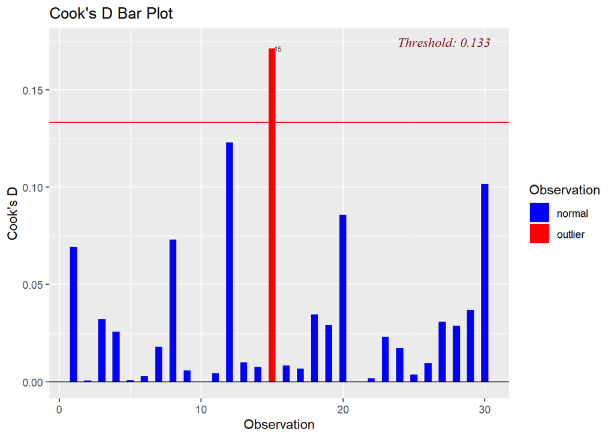

```r
ols_plot_cooksd_bar(model)
```

# Cook's distance:

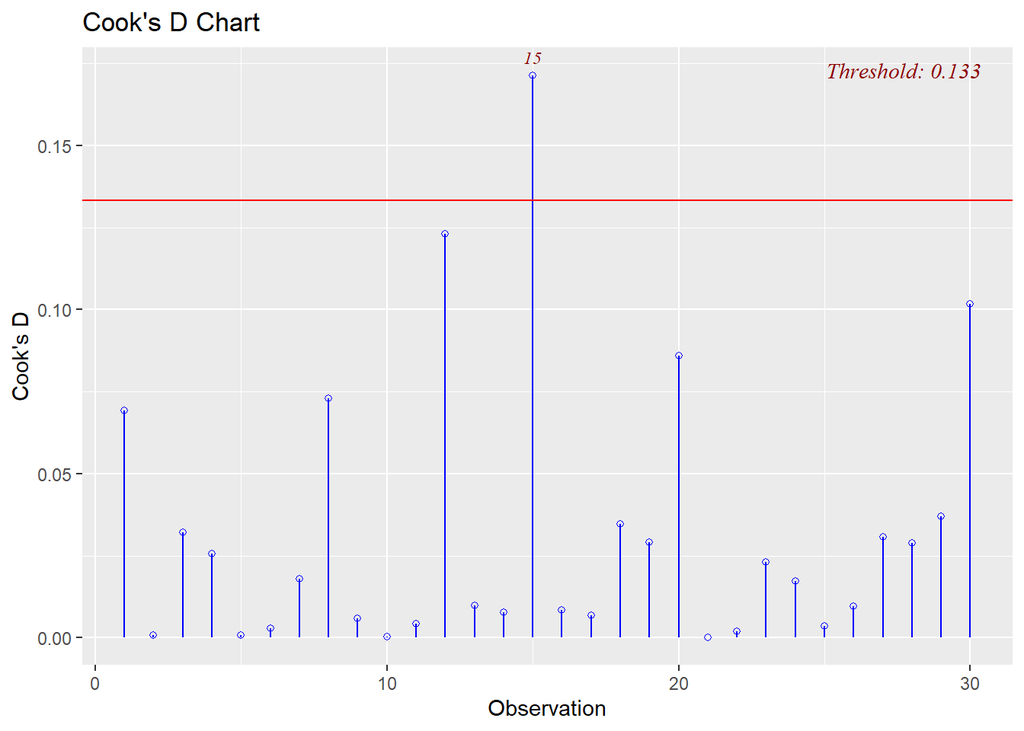

```r
ols_plot_cooksd_chart(model)
```

# DFBETa:

#### Description

Panel of plots to detect influential observations using DFBETAs.

```
ols_plot_dfbetas(model)
```

#### Arguments

- `model`: An object of class lm.

#### Details

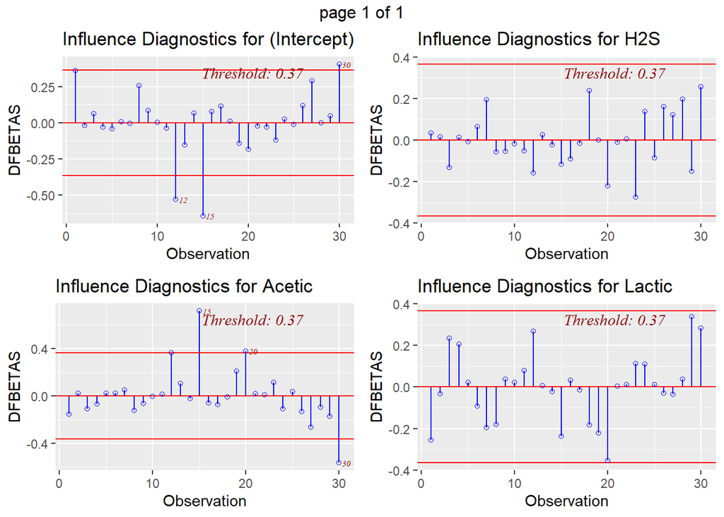

```r
ols_plot_dfbetas(model)
```

# olsrr: Leverage

The leverage of an observation is based on how much the observation's value on the predictor variable differs from the mean of the predictor variable. The greater an observation's leverage, the more potential it has to be an influential observation.

```
ols_leverage(model)
```

#### Arguments

- `model`: An object of class lm.

```r
ols_leverage(model)
```

```
##  [1] 0.17525784 0.07593130 0.05994339 0.08829409 0.12879533 0.23036705
##  [7] 0.20709897 0.08333780 0.08291114 0.12013909 0.06531941 0.14929496
## [13] 0.14821335 0.04332811 0.09000337 0.15153827 0.08934443 0.06198950
## [19] 0.08249992 0.26029095 0.14521419 0.03912430 0.20545696 0.23343680
## [25] 0.08406925 0.26606306 0.14973461 0.07036401 0.19818511 0.21445340
```

# Studentized residuals vs leverage plot

#### Description

Graph for detecting outliers and/or observations with high leverage.

```
ols_plot_resid_lev(model)
```

# Studentized residuals vs leverage plot

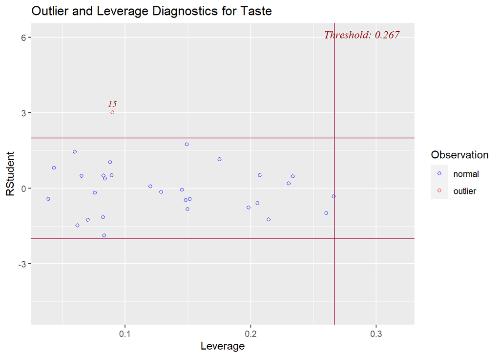

```r
ols_plot_resid_lev(model)
```

# olsrr: PRESS

#### Description

PRESS (prediction sum of squares) tells you how well the model will predict new data.

#### Usage

```
ols_press(model)
```

# Collinearity diagnostics

#### Collinearity

Variance inflation factor, tolerance, eigenvalues and condition indices.

#### Details

- Collinearity implies two variables are near perfect linear combinations of one another.
- Multicollinearity involves more than two variables.
- In the presence of multicollinearity, regression estimates are unstable and have high standard errors.

# Collinearity diagnostics

- `ols_coll_diag(model)`
- `ols_vif_tol(model)`
- `ols_eigen_cindex(model)`

# Collinearity diagnostics

```r
# vif and tolerance
ols_vif_tol(model)
```

```
##   Variables Tolerance      VIF
## 1    Acetic 0.5459740 1.831589
## 2       H2S 0.5019577 1.992200
## 3    Lactic 0.5160194 1.937912
```

# Collinearity diagnostics

```r
# eigenvalues and condition indices

ols_eigen_cindex(model) %>%
  kable( format = "markdown",digits=4)
```

| Eigenvalue | Condition Index | intercept | Acetic | H2S | Lactic |
| --- | --- | --- | --- | --- | --- |
| 3.9154 | 1.0000 | 0.0006 | 0.0004 | 0.0034 | 0.0014 |
| 0.0646 | 7.7878 | 0.0347 | 0.0072 | 0.5673 | 0.0000 |
| 0.0165 | 15.3968 | 0.0698 | 0.0154 | 0.2826 | 0.9483 |
| 0.0036 | 33.1344 | 0.8950 | 0.9770 | 0.1466 | 0.0504 |

# Collinearity diagnostics

```r
# collinearity diagnostics
ols_coll_diag(model)
```

```
## Tolerance and Variance Inflation Factor
## ---------------------------------------
##   Variables Tolerance      VIF
## 1    Acetic 0.5459740 1.831589
## 2       H2S 0.5019577 1.992200
## 3    Lactic 0.5160194 1.937912
##
##
## Eigenvalue and Condition Index
## ------------------------------
##    Eigenvalue Condition Index    intercept       Acetic        H2S       Lactic
## 1 3.915360446         1.00000 0.0005615356 0.0003642985 0.00344925 1.365207e-03
## 2 0.064557155         7.78778 0.0347152460 0.0072159623 0.56732059 2.694277e-05
## 3 0.016516138        15.39684 0.0697512251 0.0154437761 0.28263569 9.482560e-01
## 4 0.003566261        33.13441 0.8949719933 0.9769759631 0.14659447 5.035184e-02
```